# Random Networks

Jake L. Weissman

May 21, 2020

Today we are going to generate some random networks. Colloquially, when people say “random” they often mean “uniformly distributed” rather than “stochastic”. Importantly, there are many different ways to stochastically generate a network, and we will discuss a few day.

The point of this lesson is to get you think about the processes generating your own networks, and how you might characterize them (and give you a couple places to look when starting with these analyses). If you want a rigorous mathematical treatment of random networks I recommend any of the textbooks/courses listed in the extended resources section on the wiki (most textbooks dedicate a significant amount of space to these topics). **Importantly, a typical graduate-level network science course would spend several weeks at a minimum on the topics I introduce here.**

First let’s load in the packages we will be working with. This lesson will mostly use `igraph`, though we again use the example gut network provided with `SpiecEasi`. I’ll also briefly introduce the `randnet` package at the end of the lesson for fitting stochastic block models.

```r
#Make sure installed
if("igraph" %in% rownames(installed.packages()) == FALSE){install.packages("igraph")}
if("SpiecEasi" %in% rownames(installed.packages()) == FALSE){devtools::install_github("zdk123/SpiecEasi")}
if("randnet" %in% rownames(installed.packages()) == FALSE){install.packages("randnet")}

#load
library(SpiecEasi)
library(igraph)
library(randnet)
```

## Erdos-Reyni Networks

The Erdos-Reyni random network model is what people usually mean when they say “random network”. This type of network can be generated in two ways:  
1. Setting a number of edges `L` and randomly placing them between nodes  
2. Setting a probability `p` that any two nodes are connected by an edge

We will use approach 2, which is a little easier to work with mathematically and is more widely used (though #1 is the original definition).

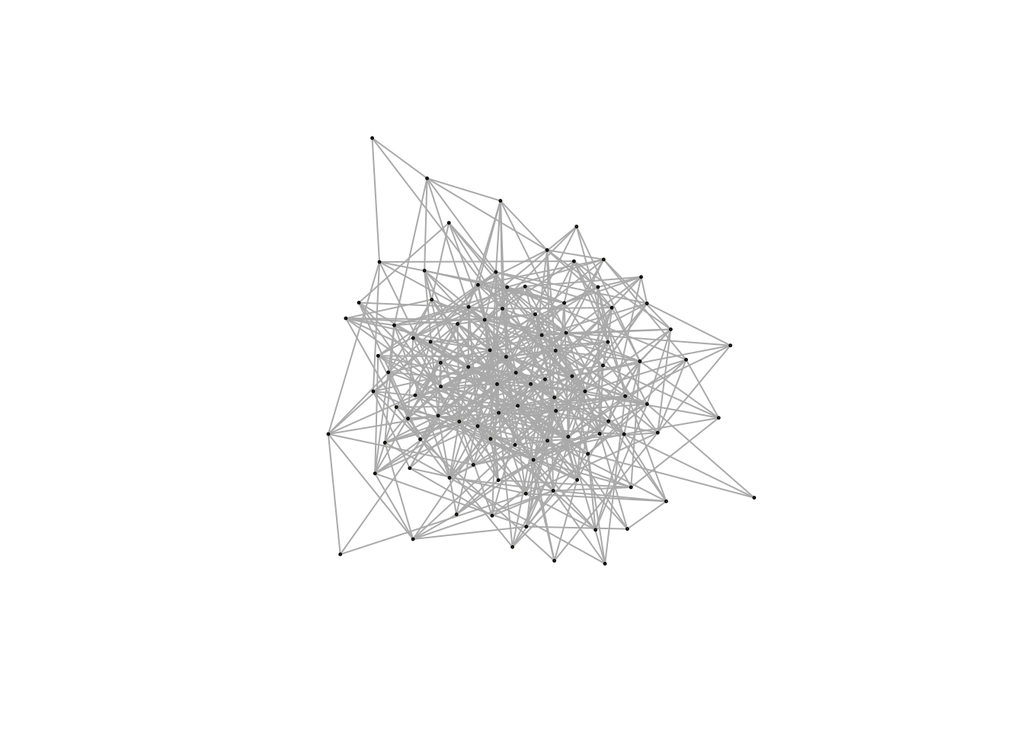

```r
n <- 100
p <- 0.1
er.net <- erdos.renyi.game(n, p, type = "gnp")
plot(er.net,
     vertex.label=NA,
     vertex.size=1)
```

Not particularly exciting as far as networks go (not much interesting structure in terms of hubs, clusters). Even so, there are some interesting properties of this type of network. For example, there is a “phase transition” around p=0.01 where the network goes from mostly disconnected to mostly connected in a single component (look up percolation theory if you are interested in learning more).

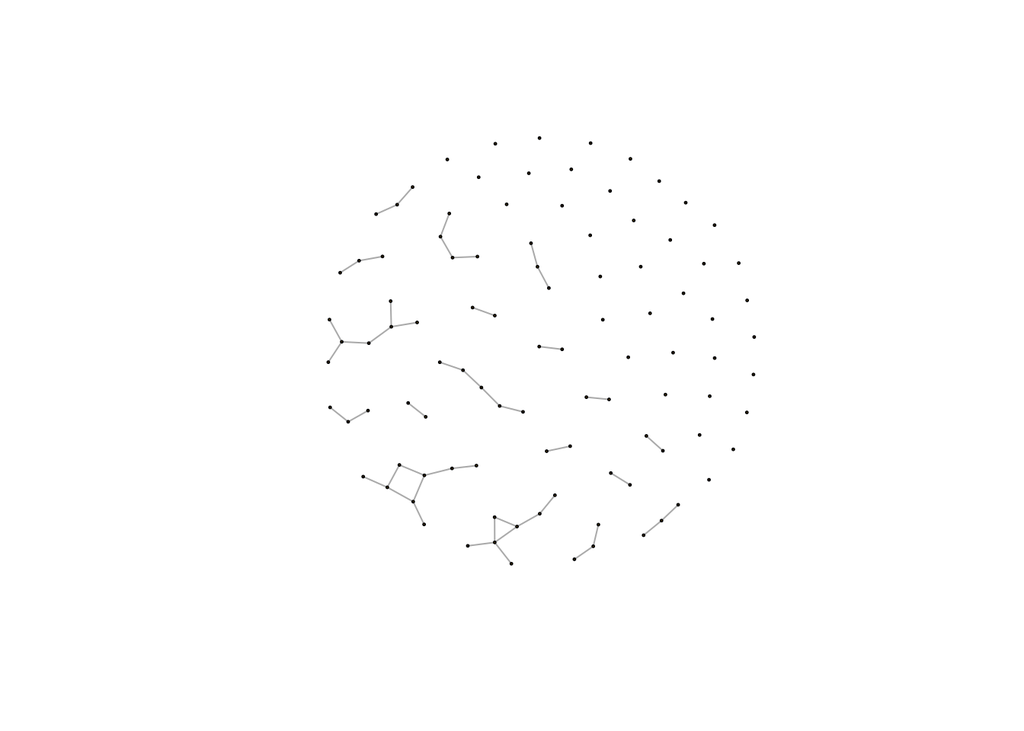

```r
n <- 100
p <- 0.01
er.net <- erdos.renyi.game(n, p, type = "gnp")
plot(er.net,
     vertex.label=NA,
     vertex.size=1)
```

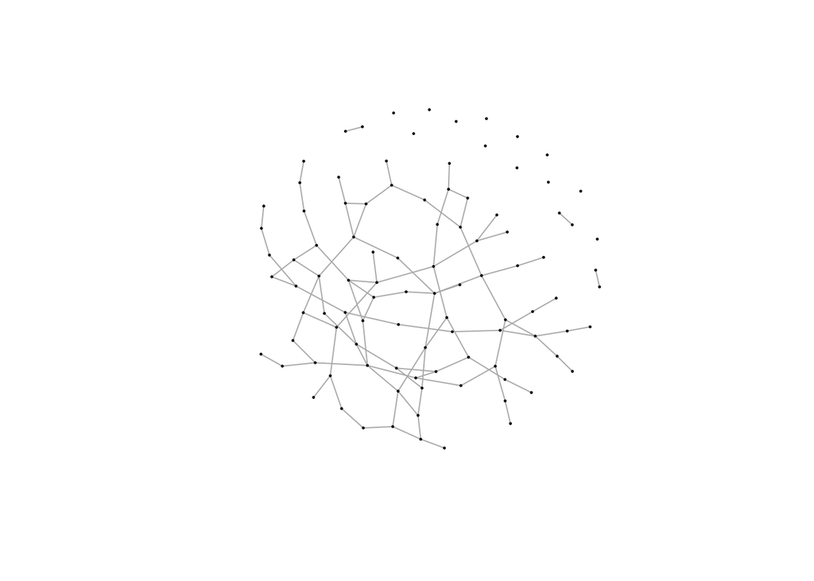

```r
n <- 100
p <- 0.02
er.net <- erdos.renyi.game(n, p, type = "gnp")
plot(er.net,
     vertex.label=NA,
     vertex.size=1)
```

One way people often analyze network structure is by looking at the degree distribution (the probability distribution of how likely a node is to have a specific degree).

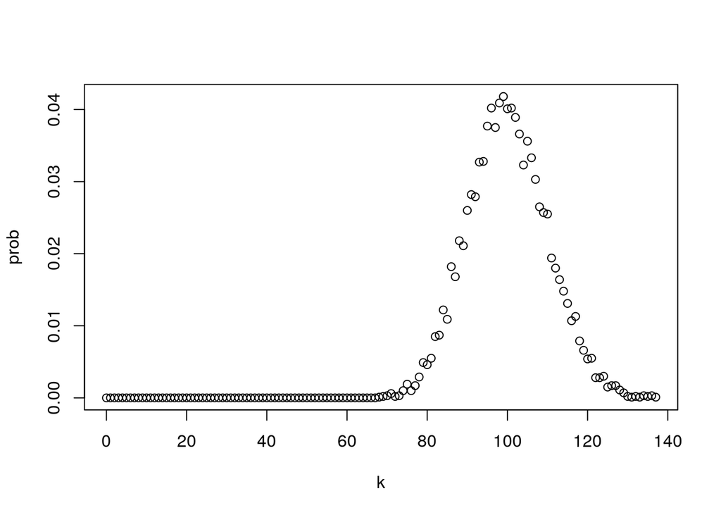

```r
# Really big, really sparse Erdos-Reyni Network
n <- 10000
p <- 0.01
er.net <- erdos.renyi.game(n, p, type = "gnp")

degree_df <- data.frame(k = 1:length(degree.distribution(er.net)) - 1,
                        prob = degree.distribution(er.net))

plot(prob ~ k, data=degree_df)
```

For random network models, there is usually an expected degree distribution associated with the model. For example, for sparse Erdos-Reyni networks the degree distribution is well approximated by a Poisson distribution with rate parameter lambda equal to the mean degree of the network (which should equal p(n-1)).

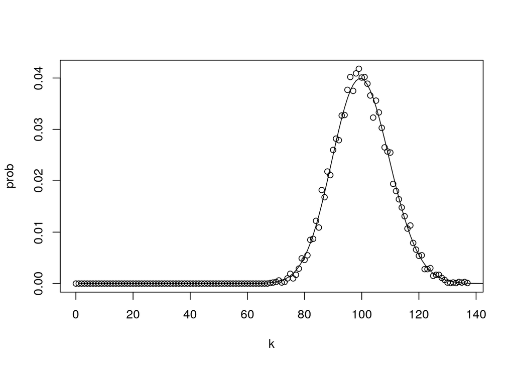

```r
k_mean <- p*(n-1)
theoretical_degree_df <- data.frame(k=1:150,
                                    prob=dpois(x=1:150,lambda=k_mean))
plot(prob ~ k, data=degree_df)
lines(prob ~ k, data=theoretical_degree_df)
```

This is one good way to check if your network resembles an Erdos-Reyni network or has some immediately-apparent complicated structure.

## The Barabasi-Albert Model (Preferential Attachement)

Often, the networks we are interested in have “hubs” - specific nodes with very high degree. You won’t see these hubs form with the Erdos-Reyni model above, since all nodes tend to have similar degree. Networks with hubs generally have “heavy-tailed” degree distributions (I’ll show an example in a moment).

One simple way to generate a random network with hubs is the Barabasi-Albert algorithm. Under this algorithm you start with a seed network and iteratively add nodes. For each added node, you connect it to other nodes in the network with a probability proportional to their degree (see [the Barabasi textbook](http://networksciencebook.com/chapter/5#barabasi-model) for details). Thus nodes with high degree accumulate new connections (a “rich-get-richer” type scenario), leading to the formation of hubs.

Let’s look at an example

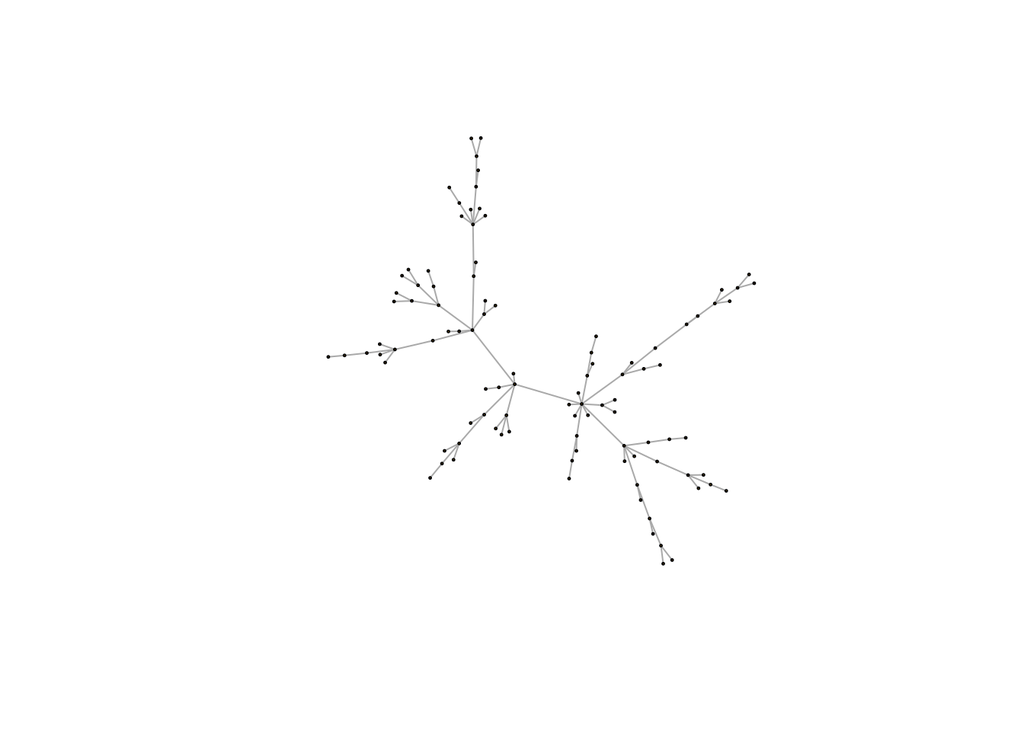

```r
n <- 100
ba.net <- barabasi.game(n, directed = F)
plot(ba.net,
     vertex.label=NA,
     vertex.size=1)
```

What does the degree distribution of a network built under this algorithm look like?

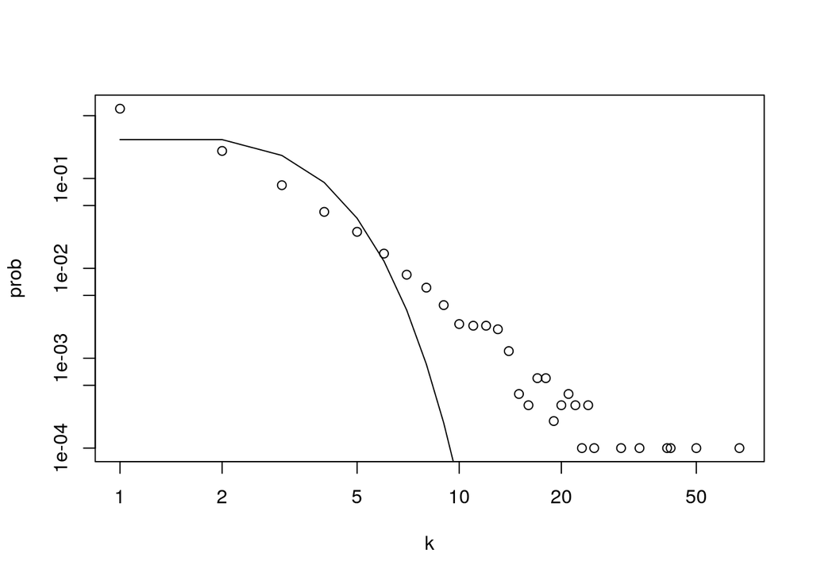

```r
n <- 10000
ba.net <- barabasi.game(n, directed = F)
degree_df <- data.frame(k = 1:length(degree.distribution(ba.net)) - 1,
                        prob = degree.distribution(ba.net))

k_mean <- mean(degree(ba.net))
theoretical_degree_df <- data.frame(k=1:150,
                                    prob=dpois(x=1:150,lambda=k_mean))
plot(prob ~ k, data=degree_df,log="xy")
lines(prob ~ k, data=theoretical_degree_df,log="xy")
```

The curved line is the theoretical fit of the poisson distribution (unlike with the E-R model, it is NOT a good fit here). Notice that we have log-log scaled our data, and get an approximately linear distribution. This corresponds to a “power-law”, and network scientists would refer to this as a “scale-free” distribution (meaning it has infinite variance, i.e., no “scale” of observation captures it; honestly, just start with the [wikipedia page](https://en.wikipedia.org/wiki/Scale-free_network)).

Fitting a power law may seem simple (it’s just a line on a log-log plot), but you should proceed with caution. Many have tried to fit power laws without being rigorous. I’m not going to get into it here, but the [powRlaw](https://cran.r-project.org/web/packages/poweRlaw/index.html) has a nice [vignette](https://cran.r-project.org/web/packages/poweRlaw/vignettes/b_powerlaw_examples.pdf) if you are interested.

There are a LOT of variants of/extensions to the BA model (see the [Barabasi Textbook](http://networksciencebook.com/chapter/6#evolving-networks)). Feel free to read up on them if you want. Its worth thinking about what processes are leading to the network you are studying (even if just as an intellectual excercise).

## Stochastic Block Models

Something we’ve talked about quite a bit so far in office hours is community-detection. So how do you generate a random network with communities?

The stochastic block model is basically the Erdos-Reyni model with communities. You pre-specify some number of communities *K* and a *KxK* matrix whose entries describe the probability of edges within (on the diagonal) or between (off the diagonal) communities. Basically, its a bunch of Erdos-Reyni networks that you then connect at random.

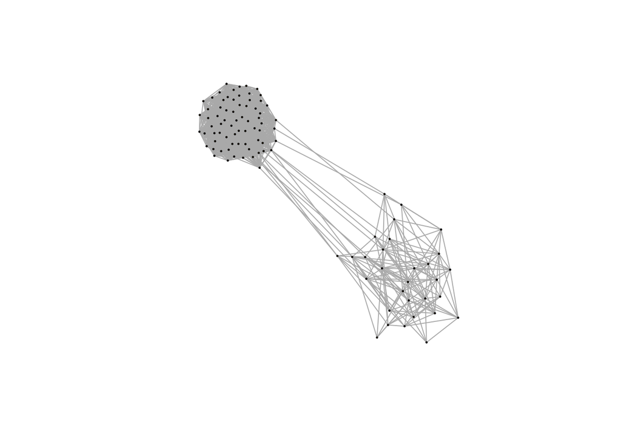

```r
pm <- cbind( c(.3, .01), c(.01, .5) )
sbm.net <- sample_sbm(n=100, pref.matrix=pm, block.sizes=c(30,70))
plot(sbm.net,
     vertex.label=NA,
     vertex.size=1)
```

What do their degree distributions look like? Well, this one is bimodal (one peak for each cluster - each peak roughly Poisson-distributed) - why do you think our theoretical prediction is a little off for the lower peak?

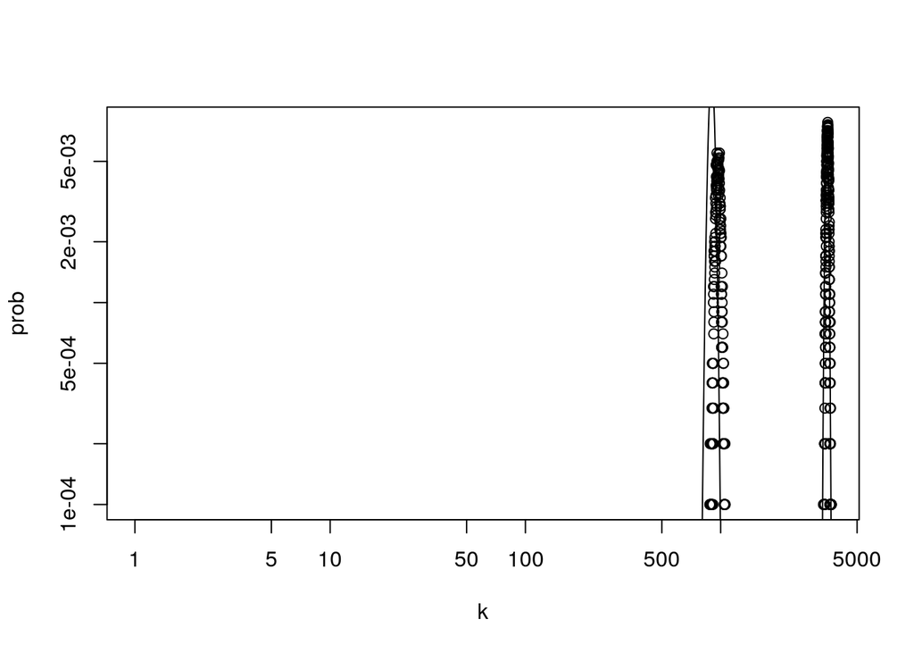

```r
pm <- cbind( c(.3, .01), c(.01, .5) )
sbm.net <- sample_sbm(n=10000, pref.matrix=pm, block.sizes=c(3000,7000))
degree_df <- data.frame(k = 1:length(degree.distribution(sbm.net)) - 1,
                        prob = degree.distribution(sbm.net))

k_mean1 <- 0.3*(3000-1)
theoretical_degree_df1 <- data.frame(k=1:5000,
                                    prob=dpois(x=1:5000,lambda=k_mean1))
k_mean2 <- 0.5*(7000-1)
theoretical_degree_df2 <- data.frame(k=1:5000,
                                    prob=dpois(x=1:5000,lambda=k_mean2))

plot(prob ~ k, data=degree_df,log="xy")
lines(prob ~ k, data=theoretical_degree_df1)
lines(prob ~ k, data=theoretical_degree_df2)
```

In fact, people often fit stochastic block models (or more complicated variants) to their data to detect communities. Because these models are generative, and have a strong statistical foundation/justification, they are a nice choice for community detection. There are a lot of R packages that will run an SBM for you, and most do not come with extensive documentation - probably why you haven’t used them before. Here’s an example from one package that will do it for you (`randnet`).

```r
pm <- cbind( c(.3, .01), c(.01, .5) )
sbm.net <- sample_sbm(n=100, pref.matrix=pm, block.sizes=c(30,70))

#Fit SBM with randnet package
#adapted from: https://methods.sagepub.com/dataset/howtoguide/sbm-in-karate-1977

# First get the optimal number of clusters
bhmc <- BHMC.estimate(as_adjacency_matrix(sbm.net),15)
bhmc
```

```
## $K
## [1] 2
##
## $values
##  [1] -123.37981  -12.80602   12.78827   17.47288   19.06230   21.04929
##  [7]   22.01958   22.61512   24.39686   24.93400   25.40834   26.07742
## [13]   26.60187   27.45232   28.52756
```

```r
# Now fit your SBM with the desired number of clusters (really the "degree corrected SBM" according to their documentation)
sbm.fit <- reg.SSP(as_adjacency_matrix(sbm.net, sparse=FALSE), K=bhmc$K)
sbm.fit$cluster
```

```
##   [1] 2 2 2 2 2 2 2 2 2 2 2 2 2 2 2 2 2 2 2 2 2 2 2 2 2 2 2 2 2 2 1 1 1 1 1 1 1
##  [38] 1 1 1 1 1 1 1 1 1 1 1 1 1 1 1 1 1 1 1 1 1 1 1 1 1 1 1 1 1 1 1 1 1 1 1 1 1
##  [75] 1 1 1 1 1 1 1 1 1 1 1 1 1 1 1 1 1 1 1 1 1 1 1 1 1 1
```

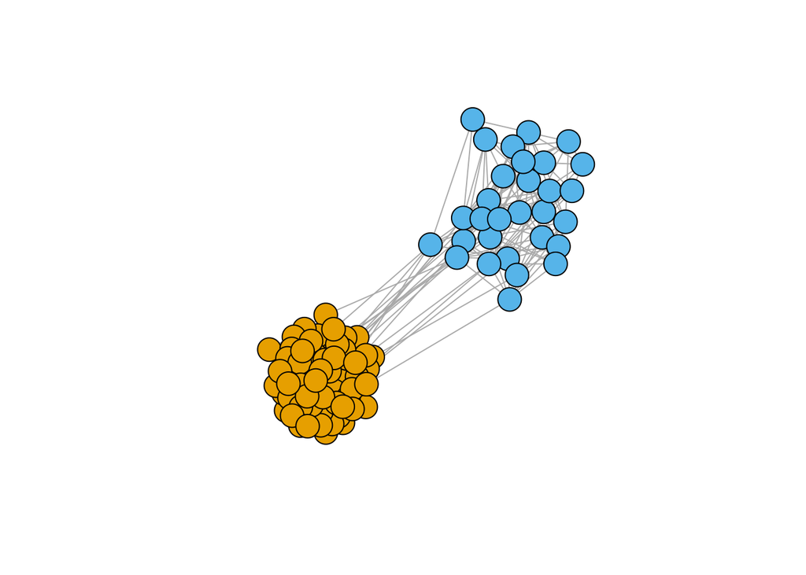

```r
plot(sbm.net,
     vertex.label=NA,
     vertex.color = sbm.fit$cluster)
```

SBMs are in themselves a large field of research, so go do some reading.

## Bonus

Try looking at the degree distribution of the SpiecEasi network we made a couple weeks ago (don’t worry about edge weights). What shape does it have?